# 2nd Assignment of ‘Reproducible Research’

Impact of Storm Events on Health and Economy

Hauer-Glocke

21 Juli 2017

# Synopsis - Overview Data Analysis

My analysis consists of two parts:

1. The Loading and Preparation of the Data (Data Processing)
2. Data Analysis and Answering of Research Questions
- Harmful events with respect to the people’s health
- Economic consequences of weather events

The analysis comes to the result that Tornados have the by far biggest influence on people’s health. Excessive heat, Thunderstorm Winds and Floods are also significantly harming event types. With respect to economic consequences, it can be observed that biggest property damages are reportedly caused by tornados, wild fires and hails, while crop damages are caused by Wetness and Wind related events.

# Data Processing

- The Loading and Preparation of the Data (Data Processing)
1. Loading of Data
2. Adjustments and Selection of Variables
3. Analysis of Data Skewness

The data is loaded directly from the server. In order to make the data workable, I adjusted variable names and excluded summary events, which decreases the number of different events significantly. Furthermore, I created the damage variables out of the for relating variables from the dataset, where the description indicated an exponential variable and the value of damage. The density graph indicates a problem with skewness in the data. Which is not further adressed here.

## Relevant Packages

```r
#Overview loaded packages
library(readr) #Reading data fast
library(dplyr) #Data Manipulation
library(lubridate) #Date Manipulation
library(ggplot2) #Additional Graphical Options
```

## Loading Data from URL

```r
#Loading of Data from URL
temp <- tempfile()
download.file("https://d396qusza40orc.cloudfront.net/repdata%2Fdata%2FStormData.csv.bz2",temp)
con <- bzfile(temp)
df <- read_csv(con)
unlink(temp)
rm(con, temp) #Drop irrelevant variables
```

## Adjust and Select the relevant Variables

```r
#Identification of relevant Variables
df1 <- df %>%
        #Selection of relevant variables (Date, Event, Healt Impact and Economic Impact)
        select(REFNUM, BGN_DATE, EVTYPE, FATALITIES, INJURIES, PROPDMG, CROPDMG, PROPDMGEXP, CROPDMGEXP) %>%
        mutate(cases_harm = FATALITIES + INJURIES)


#Adjust Variable and Event Names to "lowercase"
names(df1) <- tolower(names(df1))
df1$evtype <- tolower(df1$evtype)

#Delete summary event types
df1 <- df1 %>%
        filter(!(evtype %in% grep('summary', evtype, value=TRUE, ignore.case=TRUE)))

#Rewrite tstm to thunderstorm
df1$evtype <- gsub("tstm", "thunderstorm", df1$evtype)

#Create the Damage Variables (Property and Crop Damage)
##Build Exponent Vectors (K - Thousand (3), M - Million (6), B - Billion (9), H / h - Hundred (2),
##+ / - / ? - NA (unkown))

crop_exp <- as.vector(df1$cropdmgexp)
prop_exp <- as.vector(df1$propdmgexp)

sub <- as.data.frame(cbind(c("h", "H", "k", "K", "m", "M", "b", "B", "+", "-", "?", NA),
                           c(2, 2, 3, 3, 6, 6, 9, 9,NA,NA,NA,0)))
sub$V1 <- as.character(sub$V1)
sub$V2 <- as.character(sub$V2)

for(i in 1:length(sub$V1)){
        crop_exp[crop_exp==sub$V1[i]] <- sub$V2[i]
        prop_exp[prop_exp==sub$V1[i]] <- sub$V2[i]
}

##Create crop_dmg and prop_dmg
crop_dmg <- df1$cropdmg * 10**as.numeric(crop_exp)
prop_dmg <- df1$propdmg * 10**as.numeric(prop_exp)

##Combine in one dataset
df1 <- cbind(df1, crop_dmg, prop_dmg)
df1 <- df1 %>%
        select(refnum, bgn_date, evtype, cases_harm, fatalities, injuries, crop_dmg, prop_dmg)

#Adjust class of relevant variables
df1$bgn_date <- mdy_hms(df1$bgn_date, tz=Sys.timezone())
```

## Analysis of event Skewness

```r
#Identification of relevant Variables
plot_skew <- as.data.frame(table(df1$`bgn_date`))
```

This plot supports the expectation that the data is skewed towards newer events.

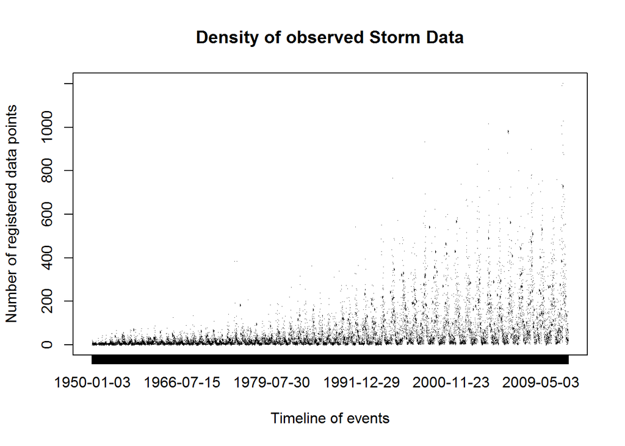

```r
plot(plot_skew,
     main = "Density of observed Storm Data",
     xlab = "Timeline of events",
     ylab = "Number of registered data points")
```

# Results

- Tornados and Excessive Heats are most harmful to American Citizens. Thunderstorm winds and floods are also very relevant for injuries.
- Biggest property damages are reportedly caused by tornados, wild fires and hails, while crop damages are caused by Wetness and Wind related events.

## 1. Across the United States, which types of events (as indicated in the EVTYPE variable) are most harmful with respect to population health?

The Harm on the Population is measured via the Number of Fatality and Injury cases, as indicated “FATALITIES” and “INJURIES”. Further I use the sum to indicate the “Harm to Population Health”.

```r
#Build Dataset for harmed Population
df_harm1 <- df1 %>%
        group_by(bgn_date) %>%
        summarise(harm_by_date = sum(cases_harm))
```

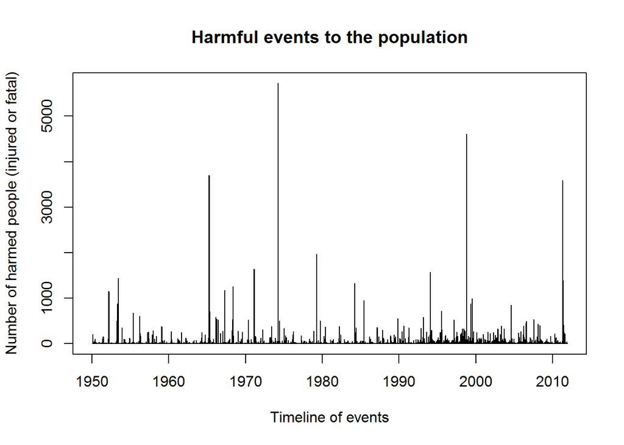

This graph shows a timeline of harmful events in the US. The harmful cases are aggregated on the day.

```r
plot(df_harm1,
     type = "l",
     main = "Harmful events to the population",
     xlab = "Timeline of events",
     ylab = "Number of harmed people (injured or fatal)")
```

```r
#What events harm the population most?
df_harm2 <- df1 %>%
        group_by(evtype) %>%
        summarise(total_harm = sum(cases_harm)) %>%
        arrange(desc(total_harm))
head(df_harm2, 3)
```

```
## # A tibble: 3 x 2
##              evtype total_harm
##               <chr>      <dbl>
## 1           tornado      96979
## 2 thunderstorm wind       9082
## 3    excessive heat       8428
```

```r
#What events cause most Deaths
df_deaths <- df1 %>%
        group_by(evtype) %>%
        summarise(total_deaths = sum(fatalities)) %>%
        arrange(desc(total_deaths))
head(df_deaths, 3)
```

```
## # A tibble: 3 x 2
##           evtype total_deaths
##            <chr>        <dbl>
## 1        tornado         5633
## 2 excessive heat         1903
## 3    flash flood          978
```

```r
#What events cause most Injuries
df_injuries <- df1 %>%
        group_by(evtype) %>%
        summarise(total_injuries = sum(injuries)) %>%
        arrange(desc(total_injuries))
head(df_injuries, 3)
```

```
## # A tibble: 3 x 2
##              evtype total_injuries
##               <chr>          <dbl>
## 1           tornado          91346
## 2 thunderstorm wind           8445
## 3             flood           6789
```

## 2. Across the United States, which types of events have the greatest economic consequences?

```r
#Events with observed damage
df1_dmg <- df1 %>%
        filter(!(is.na(crop_dmg) & is.na(prop_dmg)))
```

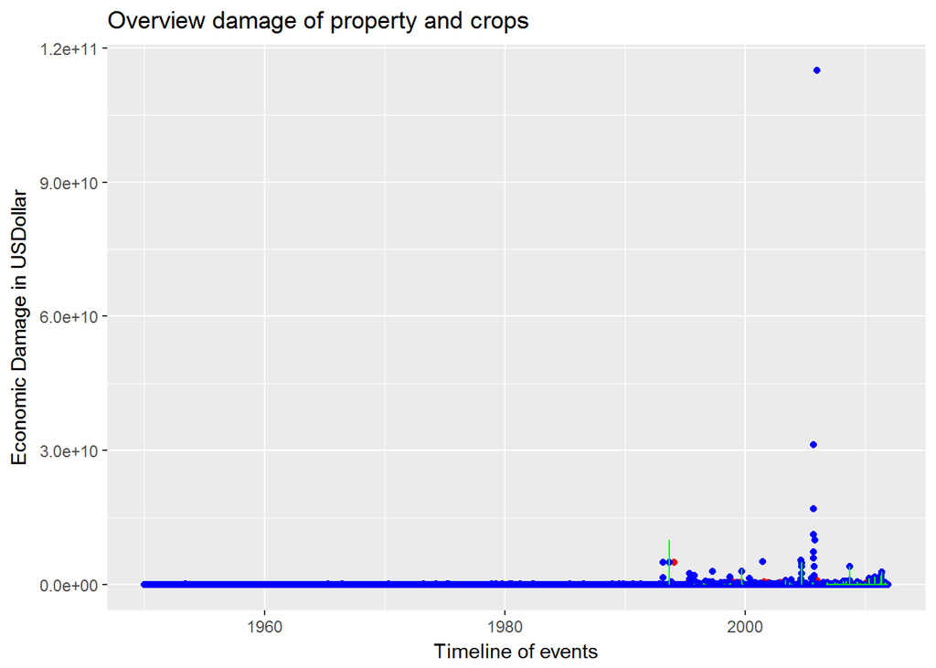

```r
g <- ggplot(data=df1_dmg) +
        geom_point(aes(x=df1_dmg$bgn_date, y=df1_dmg$crop_dmg), color="red") +
        geom_point(aes(x=df1_dmg$bgn_date, y=df1_dmg$prop_dmg), color="blue") +
        geom_line(aes(x=df1_dmg$bgn_date, y=df1_dmg$prop_dmg+df1_dmg$crop_dmg), color="green") +
        labs(x = "Timeline of events",
             y = "Economic Damage in USDollar",
             title = "Overview damage of property and crops")
g
```

```r
#Developement of Economic Consequences over all Event Types
df_crop_dmg <- df1 %>%
        group_by(evtype) %>%
        summarise(crop_damage_total = sum(crop_dmg)) %>%
        arrange(desc(crop_damage_total))

#Event Types with greatest Economic Consequences
head(df_crop_dmg, 5)
```

```
## # A tibble: 5 x 2
##                      evtype crop_damage_total
##                       <chr>             <dbl>
## 1         excessive wetness          1.42e+08
## 2   cold and wet conditions          6.60e+07
## 3 hurricane opal/high winds          1.00e+07
## 4           unseasonal rain          1.00e+07
## 5           high winds/cold          7.00e+06
```

```r
#Developement of Economic Consequences over all Event Types
df_prop_dmg <- df1 %>%
        group_by(evtype) %>%
        summarise(prop_damage_total = sum(prop_dmg)) %>%
        arrange(desc(prop_damage_total))

#Event Types with greatest Economic Consequences
head(df_prop_dmg, 5)
```

```
## # A tibble: 5 x 2
##                               evtype prop_damage_total
##                                <chr>             <dbl>
## 1 tornadoes, thunderstorm wind, hail         1.600e+09
## 2                         wild fires         6.241e+08
## 3                          hailstorm         2.410e+08
## 4                    high winds/cold         1.105e+08
## 5                        major flood         1.050e+08
```